# Pysch 755 Final

# Project Overview

This project focuses on the importance of fraud detection with automotive insurance. Insurance fraud is a problem that can cost companies billions of dollars. This project focuses on the scope of automated fraud detection with different factors. In order to find this relationship, we conducted a neural network to detect when fraudulent claims were coming based on certain car characteristics.

# Research Question

Can we automatically detect, with a high accuracy, a model for insurance fraud, based on the focal predictors, ‘auto_year’, ‘auto_make’ and ‘witnesses’ along with all of the other predictors.

# Set up

## Set up Global Options and import packages

```r
options(conflicts.policy = "depends.ok")
devtools::source_url("https://github.com/jjcurtin/lab_support/blob/main/fun_ml.R?raw=true")
```

```
ℹ SHA-1 hash of file is "32a0bc8ced92c79756b56ddcdc9a06e639795da6"
```

```r
tidymodels_conflictRules()
devtools::source_url("https://github.com/jjcurtin/lab_support/blob/main/fun_plots.R?raw=true")
```

```
ℹ SHA-1 hash of file is "def6ce26ed7b2493931fde811adff9287ee8d874"
```

```r
devtools::source_url("https://github.com/jjcurtin/lab_support/blob/main/fun_eda.R?raw=true")
```

```
ℹ SHA-1 hash of file is "c045eee2655a18dc85e715b78182f176327358a7"
```

```r
library(tidyverse)
library(tidymodels)
library(yardstick)
library(xfun, include.only = "cache_rds")
library(keras, exclude = "get_weights")
library(magrittr, exclude = c("set_names", "extract"))
library(themis)
library(datadictionary)
path_data <- "data"
theme_set(theme_classic())
options(tibble.width = Inf, dplyr.print_max=Inf)
rerun_setting <- FALSE

cl <- parallel::makePSOCKcluster(parallel::detectCores(logical = FALSE))
doParallel::registerDoParallel(cl)
```

In addition, I set up some parallel processing to help speed up computational cost of running these neural networks. ## Read in the Data

```r
data_all <- read_csv(here::here(path_data, 'insurance_claims.csv'), show_col_types = FALSE) |>
  janitor::clean_names() |> glimpse()
```

```
Rows: 1,000
Columns: 40
$ months_as_customer          <dbl> 328, 228, 134, 256, 228, 256, 137, 165, 27…
$ age                         <dbl> 48, 42, 29, 41, 44, 39, 34, 37, 33, 42, 42…
$ policy_number               <dbl> 521585, 342868, 687698, 227811, 367455, 10…
$ policy_bind_date            <date> 2014-10-17, 2006-06-27, 2000-09-06, 1990-…
$ policy_state                <chr> "OH", "IN", "OH", "IL", "IL", "OH", "IN", …
$ policy_csl                  <chr> "250/500", "250/500", "100/300", "250/500"…
$ policy_deductable           <dbl> 1000, 2000, 2000, 2000, 1000, 1000, 1000, …
$ policy_annual_premium       <dbl> 1406.91, 1197.22, 1413.14, 1415.74, 1583.9…
$ umbrella_limit              <dbl> 0e+00, 5e+06, 5e+06, 6e+06, 6e+06, 0e+00, …
$ insured_zip                 <dbl> 466132, 468176, 430632, 608117, 610706, 47…
$ insured_sex                 <chr> "MALE", "MALE", "FEMALE", "FEMALE", "MALE"…
$ insured_education_level     <chr> "MD", "MD", "PhD", "PhD", "Associate", "Ph…
$ insured_occupation          <chr> "craft-repair", "machine-op-inspct", "sale…
```

[output cut: 27 more lines]

```r
skimr::skim(data_all)
```

Data summary

| Name | data_all |
| --- | --- |
| Number of rows | 1000 |
| Number of columns | 40 |
| _______________________ |  |
| Column type frequency: |  |
| character | 19 |
| Date | 2 |
| logical | 1 |
| numeric | 18 |
| ________________________ |  |
| Group variables | None |

**Variable type: character**

| skim_variable | n_missing | complete_rate | min | max | empty | n_unique | whitespace |
| --- | --- | --- | --- | --- | --- | --- | --- |
| policy_state | 0 | 1 | 2 | 2 | 0 | 3 | 0 |
| policy_csl | 0 | 1 | 7 | 8 | 0 | 3 | 0 |
| insured_sex | 0 | 1 | 4 | 6 | 0 | 2 | 0 |
| insured_education_level | 0 | 1 | 2 | 11 | 0 | 7 | 0 |
| insured_occupation | 0 | 1 | 5 | 17 | 0 | 14 | 0 |
| insured_hobbies | 0 | 1 | 4 | 14 | 0 | 20 | 0 |
| insured_relationship | 0 | 1 | 4 | 14 | 0 | 6 | 0 |
| incident_type | 0 | 1 | 10 | 24 | 0 | 4 | 0 |
| collision_type | 0 | 1 | 1 | 15 | 0 | 4 | 0 |
| incident_severity | 0 | 1 | 10 | 14 | 0 | 4 | 0 |
| authorities_contacted | 0 | 1 | 4 | 9 | 0 | 5 | 0 |
| incident_state | 0 | 1 | 2 | 2 | 0 | 7 | 0 |
| incident_city | 0 | 1 | 8 | 11 | 0 | 7 | 0 |
| incident_location | 0 | 1 | 11 | 23 | 0 | 1000 | 0 |
| property_damage | 0 | 1 | 1 | 3 | 0 | 3 | 0 |
| police_report_available | 0 | 1 | 1 | 3 | 0 | 3 | 0 |
| auto_make | 0 | 1 | 3 | 10 | 0 | 14 | 0 |
| auto_model | 0 | 1 | 2 | 14 | 0 | 39 | 0 |
| fraud_reported | 0 | 1 | 1 | 1 | 0 | 2 | 0 |

**Variable type: Date**

| skim_variable | n_missing | complete_rate | min | max | median | n_unique |
| --- | --- | --- | --- | --- | --- | --- |
| policy_bind_date | 0 | 1 | 1990-01-08 | 2015-02-22 | 2002-04-01 | 951 |
| incident_date | 0 | 1 | 2015-01-01 | 2015-03-01 | 2015-01-31 | 60 |

**Variable type: logical**

| skim_variable | n_missing | complete_rate | mean | count |
| --- | --- | --- | --- | --- |
| c39 | 1000 | 0 | NaN | : |

**Variable type: numeric**

| skim_variable | n_missing | complete_rate | mean | sd | p0 | p25 | p50 | p75 | p100 | hist |
| --- | --- | --- | --- | --- | --- | --- | --- | --- | --- | --- |
| months_as_customer | 0 | 1 | 203.95 | 115.11 | 0.00 | 115.75 | 199.5 | 276.25 | 479.00 | ▅▇▇▃▂ |
| age | 0 | 1 | 38.95 | 9.14 | 19.00 | 32.00 | 38.0 | 44.00 | 64.00 | ▃▇▇▃▂ |
| policy_number | 0 | 1 | 546238.65 | 257063.01 | 100804.00 | 335980.25 | 533135.0 | 759099.75 | 999435.00 | ▇▇▇▇▇ |
| policy_deductable | 0 | 1 | 1136.00 | 611.86 | 500.00 | 500.00 | 1000.0 | 2000.00 | 2000.00 | ▇▇▁▁▇ |
| policy_annual_premium | 0 | 1 | 1256.41 | 244.17 | 433.33 | 1089.61 | 1257.2 | 1415.69 | 2047.59 | ▁▃▇▃▁ |
| umbrella_limit | 0 | 1 | 1101000.00 | 2297406.60 | -1000000.00 | 0.00 | 0.0 | 0.00 | 10000000.00 | ▇▁▁▁▁ |
| insured_zip | 0 | 1 | 501214.49 | 71701.61 | 430104.00 | 448404.50 | 466445.5 | 603251.00 | 620962.00 | ▇▃▁▁▅ |
| capital_gains | 0 | 1 | 25126.10 | 27872.19 | 0.00 | 0.00 | 0.0 | 51025.00 | 100500.00 | ▇▂▃▂▁ |
| capital_loss | 0 | 1 | -26793.70 | 28104.10 | -111100.00 | -51500.00 | -23250.0 | 0.00 | 0.00 | ▁▁▅▂▇ |
| incident_hour_of_the_day | 0 | 1 | 11.64 | 6.95 | 0.00 | 6.00 | 12.0 | 17.00 | 23.00 | ▇▇▆▇▇ |
| number_of_vehicles_involved | 0 | 1 | 1.84 | 1.02 | 1.00 | 1.00 | 1.0 | 3.00 | 4.00 | ▇▁▁▅▁ |
| bodily_injuries | 0 | 1 | 0.99 | 0.82 | 0.00 | 0.00 | 1.0 | 2.00 | 2.00 | ▇▁▇▁▇ |
| witnesses | 0 | 1 | 1.49 | 1.11 | 0.00 | 1.00 | 1.0 | 2.00 | 3.00 | ▇▇▁▇▇ |
| total_claim_amount | 0 | 1 | 52761.94 | 26401.53 | 100.00 | 41812.50 | 58055.0 | 70592.50 | 114920.00 | ▃▂▇▅▁ |
| injury_claim | 0 | 1 | 7433.42 | 4880.95 | 0.00 | 4295.00 | 6775.0 | 11305.00 | 21450.00 | ▅▇▅▃▁ |
| property_claim | 0 | 1 | 7399.57 | 4824.73 | 0.00 | 4445.00 | 6750.0 | 10885.00 | 23670.00 | ▅▇▅▂▁ |
| vehicle_claim | 0 | 1 | 37928.95 | 18886.25 | 70.00 | 30292.50 | 42100.0 | 50822.50 | 79560.00 | ▃▂▇▆▁ |
| auto_year | 0 | 1 | 2005.10 | 6.02 | 1995.00 | 2000.00 | 2005.0 | 2010.00 | 2015.00 | ▇▆▇▇▆ |

We read the data in and converted all the variables to snake case for better analysis. As well as looked at some basic summary statistics for the data.

## Exploratory Data Analysis

```r
data_all  <- data_all |>
  mutate(across(where(is.character), ~replace(., . == "?", NA)),
         fraud_reported = factor(fraud_reported, levels=c('N','Y')),
         property_damage_yes = if_else(property_damage == 'NO', -.5, .5),
         police_report_available_yes = if_else(police_report_available == 'NO', -.5, .5)) |>
  select(-property_damage, -police_report_available, -'c39')

glimpse(data_all)
```

```
Rows: 1,000
Columns: 39
$ months_as_customer          <dbl> 328, 228, 134, 256, 228, 256, 137, 165, 27…
$ age                         <dbl> 48, 42, 29, 41, 44, 39, 34, 37, 33, 42, 42…
$ policy_number               <dbl> 521585, 342868, 687698, 227811, 367455, 10…
$ policy_bind_date            <date> 2014-10-17, 2006-06-27, 2000-09-06, 1990-…
$ policy_state                <chr> "OH", "IN", "OH", "IL", "IL", "OH", "IN", …
$ policy_csl                  <chr> "250/500", "250/500", "100/300", "250/500"…
$ policy_deductable           <dbl> 1000, 2000, 2000, 2000, 1000, 1000, 1000, …
$ policy_annual_premium       <dbl> 1406.91, 1197.22, 1413.14, 1415.74, 1583.9…
$ umbrella_limit              <dbl> 0e+00, 5e+06, 5e+06, 6e+06, 6e+06, 0e+00, …
$ insured_zip                 <dbl> 466132, 468176, 430632, 608117, 610706, 47…
$ insured_sex                 <chr> "MALE", "MALE", "FEMALE", "FEMALE", "MALE"…
$ insured_education_level     <chr> "MD", "MD", "PhD", "PhD", "Associate", "Ph…
$ insured_occupation          <chr> "craft-repair", "machine-op-inspct", "sale…
```

[output cut: 26 more lines]

I had to change all the missing variables in the dataset from ‘?’ to ‘NA’ which will make analyses smoother. As well as making ‘property_damage’ and ‘police_report_available’ into dummy coded variables. This will also be more useful when fitting my recipes. Then removed the original variables so that the model did not try to run those variables instead of the new ones. There was an additional variables that was called ‘c39’, which had completely NA values in response to it, so it can removed it. In addition, fraud_reported needed to be changed to a factor in order to conduct our analysis. # Creat a Data Dictionary ## Find all variable names

```r
variable_names <- colnames(data_all)
variable_names
```

```
 [1] "months_as_customer"          "age"
 [3] "policy_number"               "policy_bind_date"
 [5] "policy_state"                "policy_csl"
 [7] "policy_deductable"           "policy_annual_premium"
 [9] "umbrella_limit"              "insured_zip"
[11] "insured_sex"                 "insured_education_level"
[13] "insured_occupation"          "insured_hobbies"
[15] "insured_relationship"        "capital_gains"
[17] "capital_loss"                "incident_date"
[19] "incident_type"               "collision_type"
[21] "incident_severity"           "authorities_contacted"
[23] "incident_state"              "incident_city"
[25] "incident_location"           "incident_hour_of_the_day"
[27] "number_of_vehicles_involved" "bodily_injuries"
[29] "witnesses"                   "total_claim_amount"
[31] "injury_claim"                "property_claim"
[33] "vehicle_claim"               "auto_make"
[35] "auto_model"                  "auto_year"
[37] "fraud_reported"              "property_damage_yes"
[39] "police_report_available_yes"
```

## Define the variables

```r
variable_names <- c(
  "months_as_customer", "age", "policy_number", "policy_bind_date",
  "policy_state", "policy_csl", "policy_deductable", "policy_annual_premium",
  "umbrella_limit", "insured_zip", "insured_sex", "insured_education_level",
  "insured_occupation", "insured_hobbies", "insured_relationship", "capital_gains",
  "capital_loss", "incident_date", "incident_type", "collision_type",
  "incident_severity", "authorities_contacted", "incident_state", "incident_city",
  "incident_location", "incident_hour_of_the_day", "number_of_vehicles_involved", "property_damage_yes",
  "bodily_injuries", "witnesses", "police_report_available_yes", "total_claim_amount",
  "injury_claim", "property_claim", "vehicle_claim", "auto_make",
  "auto_model", "auto_year", "fraud_reported"
)
```

## Add descriptions

```r
variable_descriptions <- c(
  "Length of time (in months) the customer has been with the insurer",
  "Age of the primary insured person",
  "Unique identifier for the insurance policy",
  "Date the policy was bound (i.e., became active)",
  "State in which the policy was issued",
  "Combined single limit for liability coverage (e.g., '250/500')",
  "Deductible amount on the policy",
  "Annual premium charged for the policy",
  "Additional umbrella liability coverage limit",
  "ZIP code of the insured",
  "Sex of the insured (e.g., MALE, FEMALE)",
  "Highest education level attained by the insured",
  "Occupation of the insured individual",
  "Insured’s hobbies (e.g., reading, skiing)",
  "Relationship of the insured to the policyholder",
  "Declared capital gains on the account",
  "Declared capital loss on the account",
  "Date on which the incident occurred",
  "Type of incident (e.g., Collision, Theft, Hail)",
  "Type of collision (e.g., Rear-End, Side, Front)",
  "Severity level of the incident (e.g., Major, Minor)",
  "Which authority was contacted after the incident",
  "State where the incident occurred",
  "City where the incident occurred",
  "Location description of the incident",
  "Hour of day the incident occurred (0–23)",
  "Number of vehicles involved in the incident",
  "Whether there was property damage (YES, 0.5/NO, -0.5)",
  "Number of bodily injuries reported",
  "Number of witnesses to the incident",
  "Whether a police report was available (YES, 0.5/NO, -0.5)",
  "Total dollar amount claimed for the incident",
  "Dollar amount claimed for bodily injury",
  "Dollar amount claimed for property damage",
  "Dollar amount claimed for vehicle damage",
  "Make of the insured automobile (e.g., Toyota)",
  "Model of the insured automobile (e.g., Corolla)",
  "Year the insured automobile was manufactured",
  "Whether the claim was reported as fraud (Y/N)"
)
```

## Create into a table

```r
data_dictionary <- data.frame(
  `Variable_Name` = variable_names,
  `Variable_Description` = variable_descriptions,
  stringsAsFactors = FALSE
)

data_dictionary
```

```
                 Variable_Name
1           months_as_customer
2                          age
3                policy_number
4             policy_bind_date
5                 policy_state
6                   policy_csl
7            policy_deductable
8        policy_annual_premium
9               umbrella_limit
10                 insured_zip
11                 insured_sex
12     insured_education_level
13          insured_occupation
14             insured_hobbies
```

[output cut: 65 more lines]

This creates a data dictionary that we can reference when examining the variables.

# Observe Correlations

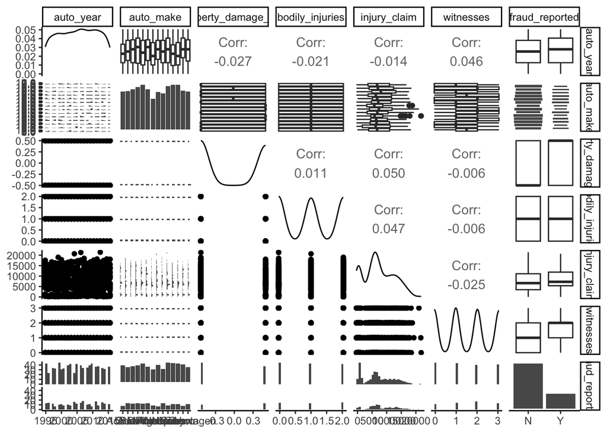

```r
sub_data <- data_all |>
  select(auto_year, auto_make,
         property_damage_yes, bodily_injuries,
         injury_claim, witnesses, fraud_reported)

GGally::ggpairs(sub_data)
```

We can see here that there are not many strong correlations with these variables. The strongest correlation that we have is for ‘injury_claim’ and ‘property_damage_yes’, with just .05. This will be useful when trying to make interactions in our recipes.

# Split the data

```r
set.seed(123456)
splits_test <- data_all |>
  initial_split(prop = .8, strata = "fraud_reported")

data_trn <- splits_test |>
  analysis()

data_test <- splits_test |>
  assessment()

split_val <- validation_split(data_trn, prop = c(3/4), strata = "fraud_reported")
```

We use a stratified split to ensure balanced representation of fraudulent and non-fraudulent cases in both training and testing sets. The .8 proportion for training provides sufficient data for model development while reserving adequate data for final evaluation. The validation split creates a further subdivision of the training data for hyperparameter tuning and model selection, helping prevent overfitting to the test set.

## Examine Distributions

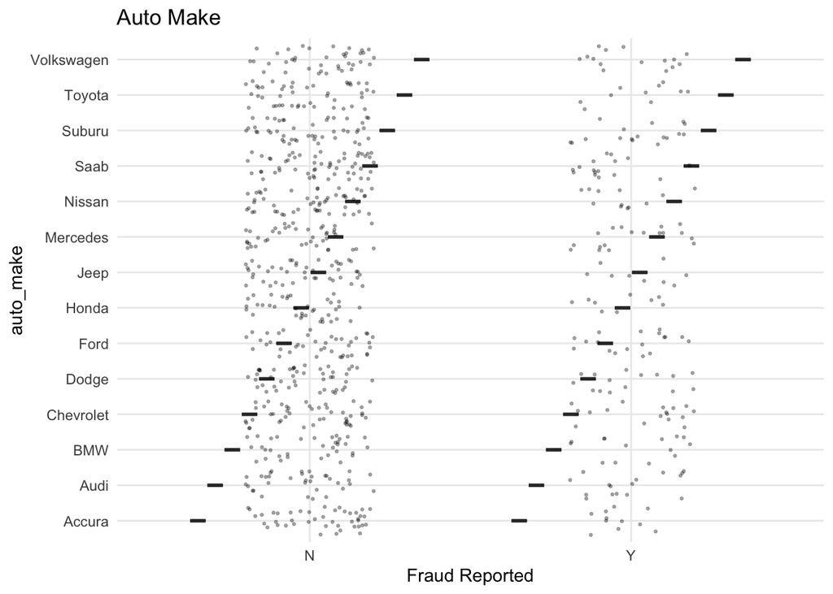

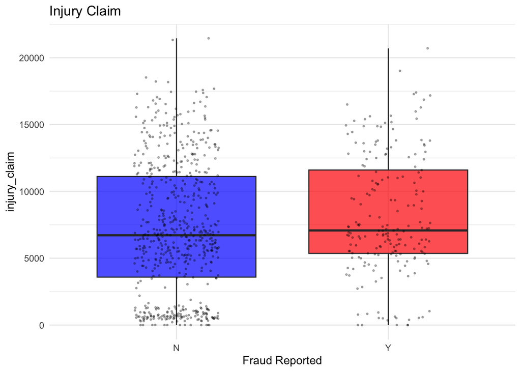

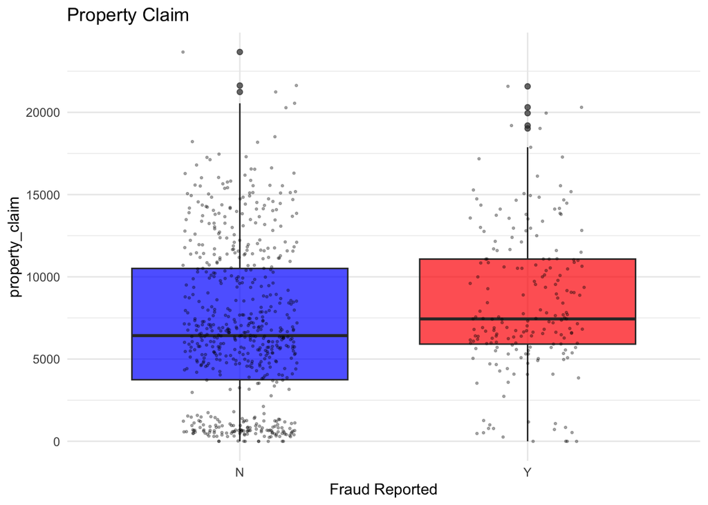

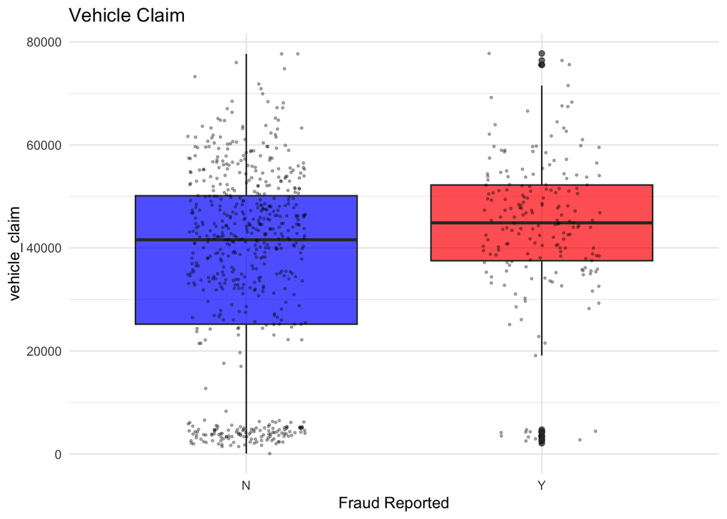

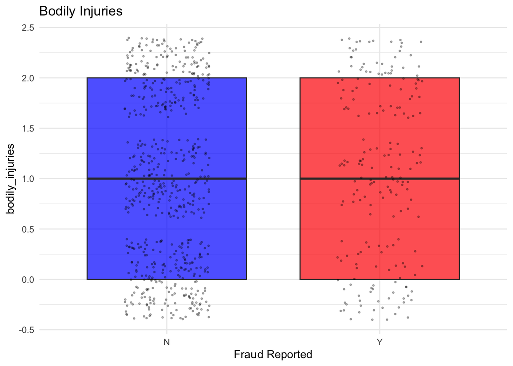

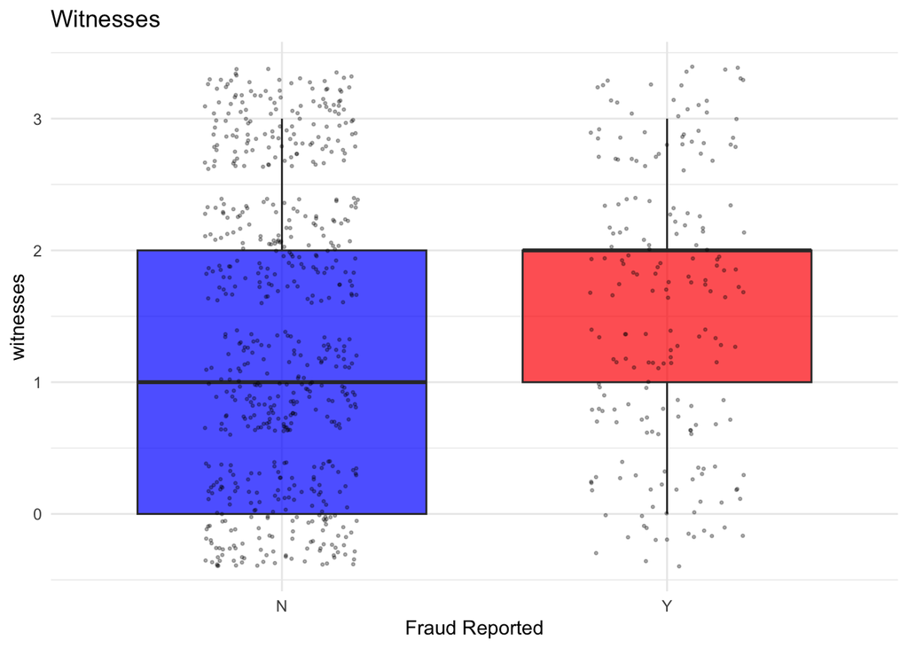

```r
key_vars <- c("auto_make", "injury_claim", "property_claim",
              "vehicle_claim", "bodily_injuries", "witnesses")

comparison_plots <- key_vars |>
  map(\(var_name) {
    data_trn |>
      ggplot(aes(x = fraud_reported, y = !!sym(var_name), fill = fraud_reported)) +
      geom_boxplot(alpha = 0.7) +
      geom_jitter(width = 0.2, alpha = 0.3, size = 0.5) +
      labs(title = str_to_title(str_replace_all(var_name, "_", " ")),
           x = "Fraud Reported",
           y = var_name) +
      theme_minimal() +
      theme(legend.position = "none") +
      scale_fill_manual(values = c("N" = "blue", "Y" = "red"))
  })

comparison_plots
```

These plots help visualize the distributions of the variables and tell whether or not what certain patterns in the data persist. For example, witnesses being present may have a strong impact on fraud detection.